# Altered Expression of Diabetes-Related Genes in Alzheimer’s Disease Brains

The Hisayama Study

Beatriz Magalhães PG32936 | Cláudio Nóvoa PG32942 | João Afonso A71874 | Marta Sampaio PG32927

14 de Junho de 2017

# 1 Introdução

Milhões de pessoas em todo o mundo sofrem de demência, sendo que se prevê a quadruplicação deste número nos próximos 25 anos [1,2]. Tal facto deve-se ao aumento da esperança média de vida e consequente aumento do número de idosos. A doença de Alzheimer (AD) é uma das formas mais comuns de demência nos adultos e, sobretudo, nos idosos, que afeta diversas zonas do cérebro, levando à perda de memória, pensamento e distúrbios comportamentais [2,3]. A incidência da AD é díspare em relação aos sexos, sendo mais notória no sexo feminino (dois terços nos USA) [3]. Atualmente, existe tratamento para a doença, porém apenas retarda a sua evolução. Por não haver ainda uma cura para a AD e porque a prevenção é crucial para a diminuição da taxa de incidência desta doença, é necessário perceber quais os fatores de risco e causas que a provocam. O metabolismo da glucose e a insulina são exemplos desses fatores, onde o organismo em situações de hiperinsulenémia e hiperglicémia, causadas por resistência à insulina, pode acelerar esse processo. Isto deve-se ao aumento da formação de placas neuríticas em conjunto com efeito da APOE ε4, que se sabe estarem envolvidas na patofisiologia de AD [1,2].

O objetivo deste trabalho passou pela análise de um conjunto de dados de expressão génica, com recurso ao programa Rstudio e aos packages do Bioconductor. Neste trabalho, foram analisadas 79 amostras, de diferentes tecidos encefálicos, provenientes de necrópsias de indivíduos residentes em Hisayma diagnosticados com aAlzheimer ou um distúrbio relacionado (controlo). Os tipos de tecido analisados correspondem ao hipocampo, córtex temporal ou córtex frontal. Apesar de o artigo analisado analisar e tirar conclusões em relação à diabetes, o dataset não possui iformação relativa a esta condição, por isso o nosso trabalho irá focar-se apenas na doença de Alzheimer.

# 2 Dados

## 2.1 **Carregamento dos e visualização dos dados**

```r
gds <- getGEO("GDS4758")
eset <- GDS2eSet(gds)
eset
```

```
## ExpressionSet (storageMode: lockedEnvironment)
## assayData: 33297 features, 79 samples
##   element names: exprs
## protocolData: none
## phenoData
##   sampleNames: GSM907858 GSM907859 ... GSM907824 (79 total)
##   varLabels: sample disease.state ... description (5 total)
##   varMetadata: labelDescription
## featureData
##   featureNames: 7896736 7896738 ... 7896730 (33297 total)
##   fvarLabels: ID Gene title ... GO:Component ID (21 total)
##   fvarMetadata: Column labelDescription
## experimentData: use 'experimentData(object)'
##   pubMedIds: 23595620
## Annotation:
```

```r
dados = exprs(eset)
dados[1:10,1:6]
```

```
##         GSM907858 GSM907859 GSM907860 GSM907854 GSM907855 GSM907856
## 7896736   7.98001   7.76415   7.54313   7.84693   7.49627   7.92109
## 7896738   5.42206   5.59312   4.77380   4.99679   5.27858   6.12362
## 7896740   6.74531   7.63617   6.46318   6.50367   6.47790   7.64459
## 7896742   9.36478   9.65509   9.67887   9.70713   9.60505   9.46327
## 7896744   8.22276   8.20467   7.77943   7.97956   7.72075   8.23660
## 7896746  11.45960  11.69570  10.49390  11.72900  11.78830  11.50600
## 7896748  11.51800  12.05400  11.71180  10.81220  12.60710  12.11760
## 7896750   7.64615   7.89694   7.49320   6.51592   8.86244   8.31554
## 7896752  11.38030  11.70280  10.79790  10.65000  11.98770  11.70950
## 7896754   9.06383   9.35470   9.29488   8.39569   8.90165   9.05549
```

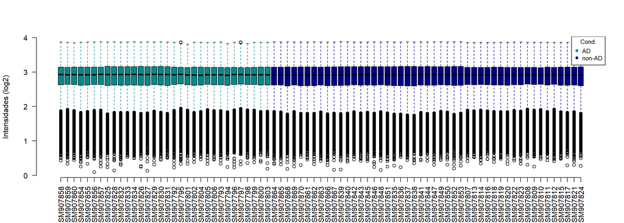

```r
c = colors()
boxplot(log2(dados), col = c[as.integer(eset$disease.state)+71], whiskcol =c[as.integer(eset$disease.state)+71], xlab = '', ylab = "Intensidades (log2)",las = 2,frame=FALSE)
legend("topright", legend=c("AD","non-AD"), col = c[c(72,73)], pch=c(19), title="Cond.",cex = 0.8)
```

**Figura 1 -** *Boxplot* dos dados.

Analisando o *Boxplot*, é possível verificar que os dados seguem uma distribuição normal, pois as caixas apresentam uma distribuição simétrica. Para além disso, as mesmas apresentam centros de dados e amplitudes semelhantes.

## 2.2 **MetaDados**

```r
vars = pData(eset)
names(vars)
```

```
## [1] "sample"        "disease.state" "tissue"        "gender"
## [5] "description"
```

Os metadados encontram-se organizados em 5 campos, nomeadamente:

```r
levels(vars$disease.state)
```

```
## [1] "Alzheimer's disease"     "non-Alzheimer's disease"
```

```r
levels(vars$tissue)
```

```
## [1] "frontal cortex"  "hippocampus"     "temporal cortex"
```

```r
levels(vars$gender)
```

```
## [1] "female" "male"
```

**Tabela 1 -** Frequência absoluta das amostras para as variáveis tecido, sexo e condição.

```r
ftable(vars$tissue, vars$gender, vars$disease.state, dnn = c("Tissue", "Gender", "Disease state"))
```

```
##                        Disease state Alzheimer's disease non-Alzheimer's disease
## Tissue          Gender
## frontal cortex  female                                 8                       9
##                 male                                   7                       9
## hippocampus     female                                 4                       5
##                 male                                   3                       5
## temporal cortex female                                 5                      11
##                 male                                   5                       8
```

# 3 Pré-processamento

## 3.1 Verificação da presença de dados omissos

```r
sum(is.na(dados))
```

```
## [1] 0
```

Concluí-se que os dados não contêm valores omissos.

## 3.2 Filtragem dos dos dados

**Retirar dados das sondas que correspondem a genes sem anotação:**

```r
genesymbol = unlist(mget(rownames(eset),hugene10sttranscriptclusterSYMBOL))
d = as.data.frame(genesymbol)
anot = na.exclude(d)
subeset = eset[rownames(anot),]
dim(subeset)
```

```
## Features  Samples
##    19991       79
```

Foi criado um subset constituído apenas pelos dados relativos a genes com anotação, utilizado na análise de expressão diferencial.

**Filtrar dados pela mediana:**

```r
sd = rowSds(exprs(subeset))
med = median(sd)
eset.f = subeset[sd>2*med,]
dim(eset.f)
```

```
## Features  Samples
##     1362       79
```

Procedeu-se, ainda, à filtração dos dados pela mediana, por forma a reduzir a quantidade de dados em estudo e, assim, tornar o processo computacionalmente mais rápido, necessário para a análise de *Machine Learning*.

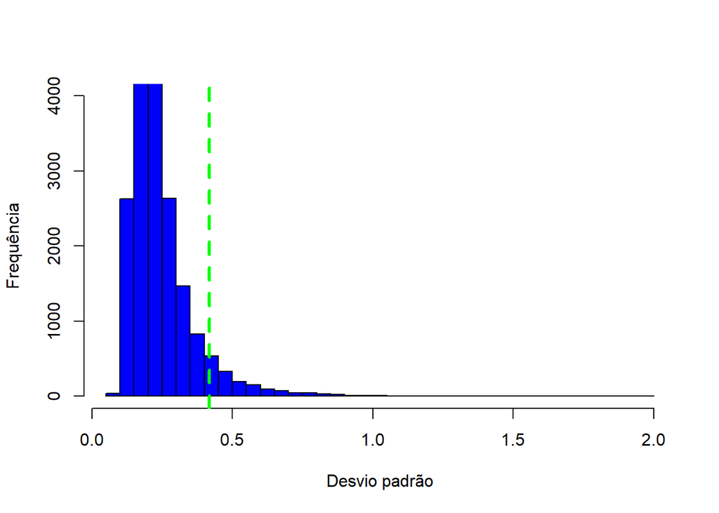

```r
hist(sd,breaks = 50,ylim = c(0,4000),col = "blue",xlab = 'Desvio padrão',ylab = 'Frequência',main = NULL)
abline(v = med*2, col = "green",lwd = 3,lty = 2)
```

**Figura 2 -** Histograma dos dados correspondentes a genes com anotação.

# 4 **Análise de Expressão Diferencial e de Enriquecimento**

Foram realizadas análises de expressão diferencial entre Doença de Alzheimer e controlo (não-Doença de Alzheimer) para os dados referentes a cada tecido (Hipocampo, Córtex Temporal e Córtex Frontal), de forma a detetar qual o mais afetado pela doença e, adicionalmente, foi realizada uma análise de expressão diferencial entre sexo Masculino e sexo Feminino para os dados da Doença de Alzheimer, para confirmar a maior predisposição desta doença no sexo Feminino. Estas análises foram realizadas utilizando o package limma, que usa modelos lineares para avaliar a expressão diferencial de experiências multifatoriais, sendo o método ideal para este tipo de análise.  
Na análise de expressão diferencial usou-se o Expression Set completo, contudo na identificação de genes siginificativamente sobreexpressos e subexpressos analisaram-se apenas os genes anotados, com *p-value* < 0.05 e *Fold Change* > *treshold*, para estar de acordo com a análise realizada no artigo. De seguida, foi realizada a análise de enriquecimento onde os genes identificados na análise anterior são comparados com outros conjuntos de genes, onde cada um destes contém genes com funções biológicas semelhantes, com objetivo de verificar se nos genes identificados existe enriquecimento estatisticamente significativo de algum/vários conjuntos. Nesta análise foi usado o package GOstats que permite a análise funcional dos genes de interesse, associando-os a termos de *Gene Ontology* (GO).

## 4.1 **Doença de Alzheimer vs Controlo**

### 4.1.1 **Hipocampo**

Criação do modelo linear, definindo controlo como referência:

```r
subsethipo = eset[,eset$tissue=="hippocampus"]
vAHipo = pData(subsethipo)
rHipo = relevel(subsethipo$disease.state, "non-Alzheimer's disease")
designAHipo = model.matrix(~rHipo)
fitAHipo = lmFit(subsethipo, designAHipo)
fit.bayesAHipo = eBayes(fitAHipo)
diffAHipo = topTable(fit.bayesAHipo, coef = 2, 1000, genelist = fitAHipo$genes$NAME)
diffAHipo.anot = diffAHipo[rownames(anot),] #genes anotados
treshold = foldchange2logratio(1.563)
genesAHipo = diffAHipo.anot[which(diffAHipo.anot$adj.P.Val < 0.05 & (diffAHipo.anot$logFC > treshold | diffAHipo.anot$logFC < -treshold)),]
dim(genesAHipo)
```

```
## [1] 83  6
```

No Hipocampo, 83 genes anotados foram considerados diferencialmente expressos entre as duas condições.

#### 4.1.1.1 **Genes sobreexpressos:**

```r
upHipo = diffAHipo.anot[which(diffAHipo.anot$adj.P.Val < 0.05 & diffAHipo.anot$logFC > treshold),]
upHipo
```

```
##             logFC  AveExpr        t      P.Value  adj.P.Val          B
## 7986350 1.0253727 9.445975 4.376592 0.0003600540 0.03632945  0.3061233
## 8078155 1.0917170 8.998624 4.279344 0.0004468662 0.03733044  0.1082273
## 8085732 0.6563969 5.733567 3.846461 0.0011734434 0.04879339 -0.7764132
```

```r
set.up = subsethipo[rownames(upHipo)]
nomes_upHipo = unlist(mget(rownames(set.up),hugene10sttranscriptclusterSYMBOL))
nomes_upHipo
```

```
##   7986350   8078155   8085732
##  "ARRDC4" "GALNT15"    "EFHB"
```

No hipocampo, 3 dos 83 genes estão sobreexpressos na Doença de Alzheimer.

#### 4.1.1.2 **Genes subexpressos:**

```r
downHipo = diffAHipo.anot[which(diffAHipo.anot$adj.P.Val < 0.05 & diffAHipo.anot$logFC < -treshold),]
downHipo[1:3,]
```

```
##              logFC   AveExpr         t      P.Value  adj.P.Val          B
## 7899841 -0.9880771 10.994105 -5.165441 6.401114e-05 0.02422731  1.8833934
## 7901342 -0.9382279  9.201656 -4.248965 4.781040e-04 0.03785047  0.0463113
## 7902205 -0.8938716  7.919788 -3.838625 1.194161e-03 0.04879339 -0.7924403
```

```r
set.down = subsethipo[rownames(downHipo)]
nomes_downHipo = unlist(mget(rownames(set.down),hugene10sttranscriptclusterSYMBOL))
nomes_downHipo[1:15]
```

```
##      7899841      7901342      7902205      7902441      7905817
##       "HPCA"     "ELAVL4"    "IL12RB2" "ST6GALNAC5"     "CHRNB2"
##      7905918      7909689      7914342      7925457      7930870
##      "EFNA3"      "SMYD2"      "FABP3"       "RGS7"     "TOMM22"
##      7948588      7948912      7950162      7959786      7965335
##       "SYT7"      "CHRM1"      "PDE2A"       "AACS"      "DUSP6"
```

No hipocampo, 80 dos 83 genes estão subexpressos na Doença de Alzheimer.

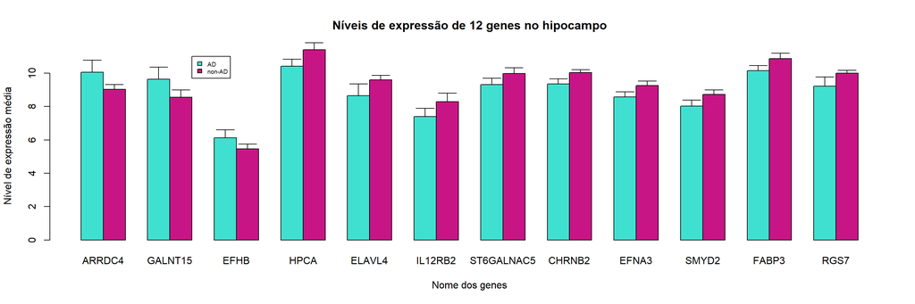

```r
ssHipo = subsethipo[c(rownames(upHipo),rownames(downHipo)),]
ssHipo1 = ssHipo[1:12,]
AD.Hipo = ssHipo1[,ssHipo$disease.state=="Alzheimer's disease"]
nAD.Hipo = ssHipo1[,ssHipo$disease.state=="non-Alzheimer's disease"]
medAD.Hipo=rowMeans(exprs(AD.Hipo))
mednAD.Hipo = rowMeans(exprs(nAD.Hipo))
dfHipo = data.frame(AD=medAD.Hipo,nAD=mednAD.Hipo)
sdevAD.Hipo = apply(exprs(AD.Hipo),1,sd)
sdevnAD.Hipo = apply(exprs(nAD.Hipo),1,sd)
sdevHipo=c()
for (i in 1:length(sdevnAD.Hipo))
  sdevHipo = c(sdevHipo,sdevAD.Hipo[i],sdevnAD.Hipo[i])
nomesHipo = unlist(mget(rownames(dfHipo),hugene10sttranscriptclusterSYMBOL))
bp.Hipo=barplot(t(dfHipo),beside=T,main="Níveis de expressão de 12 genes no hipocampo",names.arg=nomesHipo, xlab = "Nome dos genes", ylab = "Nível de expressão média",col=c("turquoise","mediumvioletred"))
legend(6,11,legend=c("AD","non-AD"),cex=0.6,fill=c("turquoise","mediumvioletred"),xpd=TRUE)
arrows(bp.Hipo,t(dfHipo)+sdevHipo, bp.Hipo, t(dfHipo), angle=90, code=1,length = 0.15,xpd=TRUE)
```

**Figura 3 -** Comparação dos níveis de expressão de 12 genes cuja expressão diferencial é significativamente diferente no hipocampo AD em relação a non-AD.

#### 4.1.1.3 **Análise de Enriquecimento para os genes sobreexpressos**

```r
entrezUniverse = unlist(mget(featureNames(eset), hugene10sttranscriptclusterENTREZID))
selectedEntrezIds.up.h = unlist(mget(rownames(upHipo), hugene10sttranscriptclusterENTREZID))
params1.up.h = new("GOHyperGParams", geneIds = selectedEntrezIds.up.h, universeGeneIds = entrezUniverse,
              annotation = "hugene10sttranscriptcluster.db", ontology = "BP", pvalueCutoff = 0.025, testDirection = "over")
hgOverHipo = hyperGTest(params1.up.h)
summary(hgOverHipo)
```

```
##       GOBPID      Pvalue OddsRatio    ExpCount Count Size
## 1 GO:0016266 0.007105921 285.12963 0.007118359     1   55
## 2 GO:0006493 0.012643811 158.28866 0.012683621     1   98
## 3 GO:0051443 0.012901010 155.07071 0.012942471     1  100
## 4 GO:0051438 0.015214296 131.05983 0.015272115     1  118
## 5 GO:0031398 0.022137873  89.35673 0.022261050     1  172
## 6 GO:1903322 0.023928888  82.51892 0.024072996     1  186
##                                                                                  Term
## 1                                                                 O-glycan processing
## 2                                                      protein O-linked glycosylation
## 3                       positive regulation of ubiquitin-protein transferase activity
## 4                                regulation of ubiquitin-protein transferase activity
## 5                                       positive regulation of protein ubiquitination
## 6 positive regulation of protein modification by small protein conjugation or removal
```

Pela análise de enriquecimento pode-se aferir que os genes sobreexpressos no hipocampo estão envolvidos em processos como a regulação positiva da atividade da ubiquitina transferase, da ubiquitinização de proteínas e modificação proteica por conjugação ou remoção de pequenas proteínas. Estas funções estão relacionadas entre si e relacionam-se com AD, visto que, a ubiquitina transferase catalisa a transferência da ubiquitina de uma proteína para outra, sendo que a ubiquitina está envolvida em inúmeros processos celulares, incluíndo memória a longo prazo e doença de Alzheimer [4].

#### 4.1.1.4 **Análise de Enriquecimento para os genes subexpressos**

```r
selectedEntrezIds.down.h = unlist(mget(rownames(downHipo), hugene10sttranscriptclusterENTREZID))
params1.down.h = new("GOHyperGParams", geneIds = selectedEntrezIds.down.h, universeGeneIds = entrezUniverse,
              annotation = "hugene10sttranscriptcluster.db", ontology = "BP", pvalueCutoff = 0.025, testDirection = "over")
hgOverHipo1 = hyperGTest(params1.down.h)
summary(hgOverHipo1)[1:10,]
```

```
##        GOBPID       Pvalue OddsRatio ExpCount Count Size
## 1  GO:0007268 6.488363e-10  8.334777 2.641817    17  567
## 2  GO:0098916 6.488363e-10  8.334777 2.641817    17  567
## 3  GO:0099536 6.846917e-10  8.303458 2.651136    17  569
## 4  GO:0099537 6.846917e-10  8.303458 2.651136    17  569
## 5  GO:0006811 1.342826e-07  4.455341 6.937682    23 1489
## 6  GO:0034220 4.390392e-07  4.935937 4.617356    18  991
## 7  GO:0098660 1.054005e-06  5.397865 3.401281    15  730
## 8  GO:0051049 1.459384e-06  3.830584 7.930111    23 1702
## 9  GO:0055085 1.596179e-06  4.155499 6.164240    20 1323
## 10 GO:0044708 1.702326e-06  7.157299 1.812464    11  389
##                                     Term
## 1         chemical synaptic transmission
## 2   anterograde trans-synaptic signaling
## 3                     synaptic signaling
## 4               trans-synaptic signaling
## 5                          ion transport
## 6            ion transmembrane transport
## 7  inorganic ion transmembrane transport
## 8                regulation of transport
## 9                transmembrane transport
## 10              single-organism behavior
```

Os genes subexpressos no hipocampo são responsáveis por funções como a transmissão sináptica e trans-sináptica, transporte de iões e regulação do transporte. Na doença de Alzheimer, sabe-se que ocorre deposição de proteína amilóide e de emaranhados neurofibrilhares, que levam à interrupção da comunicação entre neurónios (sinapse). Os emaranhados, além disso, levam à destruição de neurónios com o decorrer da doença [4]. Deste modo, apesar de a patofisiologia da doença ainda não ser totalmente conhecida, parece haver uma relação entre a diminuição da expressão destes genes e a perda das sinapses, que, no hipocampo, está associada à perda de memória, visível na doença.

### 4.1.2 **Córtex Temporal**

```r
subsetTemp = eset[,eset$tissue=="temporal cortex"]
vATemp = pData(subsetTemp)
rTemp = relevel(subsetTemp$disease.state, "non-Alzheimer's disease")
designATemp = model.matrix(~rTemp)
fitATemp = lmFit(subsetTemp, designATemp)
fit.bayesATemp = eBayes(fitATemp)
diffATemp = topTable(fit.bayesATemp, coef = 2, 1000, genelist = fitATemp$genes$NAME)
diffATemp.anot = diffATemp[rownames(anot),]
genesATemp = diffATemp.anot[which(diffATemp.anot$adj.P.Val < 0.05 & (diffATemp.anot$logFC > treshold | diffATemp.anot$logFC < -treshold)),]
ssTemp = subsetTemp[rownames(genesATemp),]
dim(genesATemp)
```

```
## [1] 8 6
```

No Córtex Temporal, 8 genes anotados foram considerados diferencialmente expressos entre as duas condições.

#### 4.1.2.1 **Genes sobreexpressos:**

```r
upTemp = diffATemp.anot[which(diffATemp.anot$adj.P.Val < 0.05 & diffATemp.anot$logFC > treshold),]
settemp.up = subsetTemp[rownames(upTemp)]
nomes_upTemp = unlist(mget(rownames(settemp.up),hugene10sttranscriptclusterSYMBOL))
nomes_upTemp
```

```
##  7948167  7973101  8009951  8117034  8120719
##  "APLNR" "RNASE6"  "ITGB4"   "GMPR"  "CD109"
```

No Córtex Temporal, 5 dos 8 genes estão sobreexpressos na Doença de Alzheimer.

#### 4.1.2.2 **Genes subexpressos:**

```r
downTemp = diffATemp.anot[which(diffATemp.anot$adj.P.Val < 0.05 & diffATemp.anot$logFC < -treshold),]
settemp.down = subsetTemp[rownames(downTemp)]
nomes_downTemp = unlist(mget(rownames(settemp.down),hugene10sttranscriptclusterSYMBOL))
nomes_downTemp
```

```
##     7974900     7982102     8135601
## "LINC00643"    "GABRA5"       "MET"
```

No Córtex Temporal, 3 dos 8 genes estão subexpressos na Doença de Alzheimer.

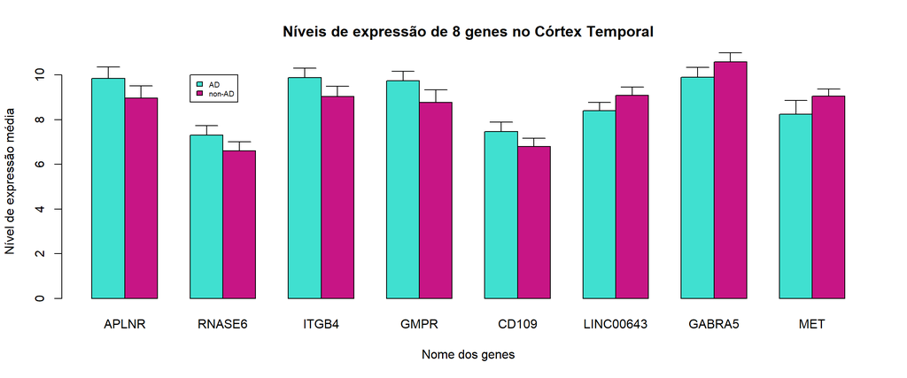

```r
ssTemp = subsetTemp[c(rownames(upTemp),rownames(downTemp)),]
AD.Temp = ssTemp[,ssTemp$disease.state=="Alzheimer's disease"]
nAD.Temp = ssTemp[,ssTemp$disease.state=="non-Alzheimer's disease"]
medAD.Temp=rowMeans(exprs(AD.Temp))
mednAD.Temp = rowMeans(exprs(nAD.Temp))
dfTemp = data.frame(AD=medAD.Temp,nAD=mednAD.Temp)
sdevAD.Temp = apply(exprs(AD.Temp),1,sd)
sdevnAD.Temp = apply(exprs(nAD.Temp),1,sd)
sdevTemp=c()
for (i in 1:length(sdevnAD.Temp))
  sdevTemp = c(sdevTemp,sdevAD.Temp[i],sdevnAD.Temp[i])
nomesTemp = unlist(mget(rownames(dfTemp),hugene10sttranscriptclusterSYMBOL))
bp.Temp=barplot(t(dfTemp),beside=T,main="Níveis de expressão de 8 genes no Córtex Temporal",names.arg=nomesTemp, xlab = "Nome dos genes", ylab = "Nível de expressão média",col=c("turquoise","mediumvioletred"))
legend(4,10,legend=c("AD","non-AD"),cex=0.6,fill=c("turquoise","mediumvioletred"),xpd=TRUE)
arrows(bp.Temp,t(dfTemp)+sdevTemp, bp.Temp, t(dfTemp), angle=90, code=1,length = 0.15,xpd=TRUE)
```

**Figura 4 -** Comparação dos níveis de expressão de 8 genes cuja expressão diferencial é significativamente diferente no córtex temporal AD em relação a non-AD.

#### 4.1.2.3 **Análise de Enriquecimento para os genes sobreexpressos**

```r
selectedEntrezIds.up.t = unlist(mget(rownames(upTemp), hugene10sttranscriptclusterENTREZID))
params1.up.t = new("GOHyperGParams", geneIds = selectedEntrezIds.up.t, universeGeneIds = entrezUniverse,
              annotation = "hugene10sttranscriptcluster.db", ontology = "BP", pvalueCutoff = 0.025, testDirection = "over")
hgOvertemp1 = hyperGTest(params1.up.t)
summary(hgOvertemp1)[1:10,]
```

```
##        GOBPID      Pvalue  OddsRatio     ExpCount Count Size
## 1  GO:0072675 0.000970434 1930.75000 0.0009706853     1    3
## 2  GO:0007369 0.001191024   60.27219 0.0553290623     2  171
## 3  GO:0072674 0.001293745 1287.08333 0.0012942471     1    4
## 4  GO:0035878 0.003231850  428.86111 0.0032356177     1   10
## 5  GO:0031581 0.003554575  385.95000 0.0035591794     1   11
## 6  GO:0010839 0.004522249  296.82692 0.0045298648     1   14
## 7  GO:0043101 0.004522249  296.82692 0.0045298648     1   14
## 8  GO:0043588 0.005479101   27.24300 0.1200414159     2  371
## 9  GO:0006144 0.006455340  203.01316 0.0064712354     1   20
## 10 GO:0097186 0.007099036  183.65476 0.0071183589     1   22
##                                                 Term
## 1                                  osteoclast fusion
## 2                                       gastrulation
## 3            multinuclear osteoclast differentiation
## 4                                   nail development
## 5                             hemidesmosome assembly
## 6  negative regulation of keratinocyte proliferation
## 7                 purine-containing compound salvage
## 8                                   skin development
## 9                purine nucleobase metabolic process
## 10                                      amelogenesis
```

No córtex temporal, a maior parte dos genes sobreexpressos estão envolvidos em processos do desenvolvimento embriológico e, portanto, não relacionados com a doença de Alzheimer. Contudo, alguns dos genes estão envolvidos na resposta inflamatória e ao stress oxidativo. Quanto ao stess oxidativo, sabe-se que este ocorre na AD e acredita-se que é um fator crítico. Potencialmente é um dos eventos mais precoces, inicia os distúrbios cognitivos e é responsável por algumas características observadas na doença. Pensa-se que os mecanismos inflamatórios têm um papel no processo degenerativo que se verifica em AD, verificando-se níveis elevados de citoquinas no plasma, placas corticais e neurónios dos doentes [4].

#### 4.1.2.4 **Análise de Enriquecimento para os genes subexpressos**

```r
selectedEntrezIds.down.t = unlist(mget(rownames(downTemp), hugene10sttranscriptclusterENTREZID))
params1.down.t = new("GOHyperGParams", geneIds = selectedEntrezIds.down.t, universeGeneIds = entrezUniverse,
              annotation = "hugene10sttranscriptcluster.db", ontology = "BP", pvalueCutoff = 0.025, testDirection = "over")
hgOverTemp2 = hyperGTest(params1.down.t)
summary(hgOverTemp2)[1:10,]
```

```
##        GOBPID       Pvalue OddsRatio     ExpCount Count Size
## 1  GO:0070494 0.0003882490  7724.500 0.0003882741     1    3
## 2  GO:0070495 0.0003882490  7724.500 0.0003882741     1    3
## 3  GO:1905098 0.0003882490  7724.500 0.0003882741     1    3
## 4  GO:1905097 0.0005176486  5149.333 0.0005176988     1    4
## 5  GO:1901299 0.0006470398  3861.750 0.0006471235     1    5
## 6  GO:0001886 0.0011645208  1930.375 0.0011648224     1    9
## 7  GO:1901298 0.0011645208  1930.375 0.0011648224     1    9
## 8  GO:0010421 0.0014232111  1544.100 0.0014236718     1   11
## 9  GO:0097468 0.0014232111  1544.100 0.0014236718     1   11
## 10 GO:0070493 0.0015525437  1403.636 0.0015530965     1   12
##                                                                       Term
## 1              regulation of thrombin-activated receptor signaling pathway
## 2     negative regulation of thrombin-activated receptor signaling pathway
## 3        negative regulation of guanyl-nucleotide exchange factor activity
## 4                 regulation of guanyl-nucleotide exchange factor activity
## 5  negative regulation of hydrogen peroxide-mediated programmed cell death
## 6                                           endothelial cell morphogenesis
## 7           regulation of hydrogen peroxide-mediated programmed cell death
## 8                         hydrogen peroxide-mediated programmed cell death
## 9             programmed cell death in response to reactive oxygen species
## 10                           thrombin-activated receptor signaling pathway
```

Os genes subexpressos no córtex temporal estão envolvidos em várias funções, como morte celular programada, regulação da via de sinalização do recetor da trombina (processo inflamatório), regulação negativa da via de sinalização de recetores acoplados à proteína G, etc. A relação entre o Alzheimer e o processo inflamatório já foi explicado anteriormente. Quanto à morte celular programada, sabe-se que há destruição de neurónios e que esse processo está muito provavelmente associado aos emaranhados neurofibrilhares e às placas amilóides, mas ainda não se sabe qual o processo que ocorre primeiro, se a destruição de neurónios, se a formação de tais estruturas [4]. Quanto à regulação da sinalização dos recetores acoplados à proteína G, estes são fundamentais nas sinapses.

## 4.2 **Córtex Frontal**

```r
subsetFront = eset[,eset$tissue=="frontal cortex"]
vAFront = pData(subsetFront)
rFront = relevel(subsetFront$disease.state, "non-Alzheimer's disease")
designAFront = model.matrix(~rFront)
fitAFront = lmFit(subsetFront, designAFront)
fit.bayesAFront = eBayes(fitAFront)
diffAFront = topTable(fit.bayesAFront, coef = 2, 1000, genelist = fitAFront$genes$NAME)
diffAFront.anot = diffAFront[rownames(anot),]
genesAFront = diffAFront.anot[which(diffAFront.anot$adj.P.Val < 0.05 & (diffAFront.anot$logFC > treshold | diffAFront.anot$logFC < -treshold)),]
dim(genesAFront)
```

```
## [1] 0 6
```

No Córtex Frontal, não foram identificados genes diferencialmente expressos entre as duas condições.

## 4.3 **Masculino vs Feminino nos casos de Doença de Alzheimer**

```r
subAD = eset[eset$disease.state=="Alzheimer's disease",]
rAD = relevel(subAD$gender, "male")
designAD = model.matrix(~rAD)
fit.AD = lmFit(subAD, designAD)
fit.bayesAD = eBayes(fit.AD)
diffAD = topTable(fit.bayesAD, coef = 2, 1000, genelist = fit.AD$genes$NAME)
diffAD.anot = diffAD[rownames(anot),]
genesAD = diffAD.anot[which(diffAD.anot$adj.P.Val < 0.05 & (diffAD.anot$logFC > treshold | diffAD.anot$logFC < -treshold)),]
dim(genesAD)
```

```
## [1] 9 6
```

### 4.3.1 **Genes sobreexpressos:**

```r
upAD = diffAD.anot[which(diffAD.anot$adj.P.Val < 0.05 & diffAD.anot$logFC > treshold),]
setAD.up = subAD[rownames(upAD),]
namesAD.up = unlist(mget(rownames(setAD.up),hugene10sttranscriptclusterSYMBOL))
namesAD.up
```

```
##   7918622   8086344   8091530   8131550   8141094   8166906   8168412
## "SLC16A1"  "CX3CR1"  "P2RY12"    "SCIN"    "PDK4"   "GPR34"     "JPX"
```

7 dos 9 genes estão sobreexpressos no género feminino.

### 4.3.2 **Genes subexpressos:**

```r
downAD = diffAD.anot[which(diffAD.anot$adj.P.Val < 0.05 & diffAD.anot$logFC < -treshold),]
setAD.down = subAD[rownames(downAD),]
namesAD.down = unlist(mget(rownames(setAD.down),hugene10sttranscriptclusterSYMBOL))
namesAD.down
```

```
## 8176578 8177137
## "USP9Y"   "UTY"
```

2 dos 9 genes estão subexpressos no género feminino.

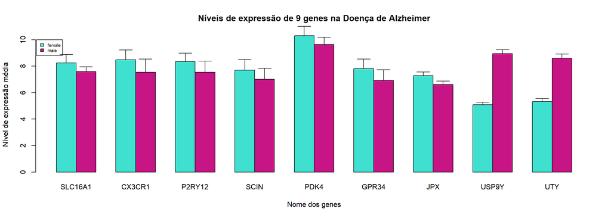

```r
ssAD = subAD[c(rownames(upAD),rownames(downAD)),]
male.g = ssAD[,ssAD$gender=="male"]
female.g = ssAD[,ssAD$gender=="female"]
medAD.male=rowMeans(exprs(male.g))
medAD.female = rowMeans(exprs(female.g))
dfg = data.frame(female=medAD.female,male=medAD.male)
sdevAD.male = apply(exprs(male.g),1,sd)
sdevAD.female = apply(exprs(female.g),1,sd)
sdevg=c()
for (i in 1:length(sdevAD.male))
  sdevg = c(sdevg,sdevAD.female[i],sdevAD.male[i])
nomesg = unlist(mget(rownames(dfg),hugene10sttranscriptclusterSYMBOL))
bp.g=barplot(t(dfg),beside=T,main="",names.arg=nomesg, xlab = "Nome dos genes", ylab = "Nível de expressão média",col=c("turquoise","mediumvioletred"))
legend(0,10,legend=c("female","male"),cex=0.6,fill=c("turquoise","mediumvioletred"),xpd=TRUE)
title("Níveis de expressão de 9 genes na Doença de Alzheimer")
arrows(bp.g,t(dfg)+sdevg, bp.g, t(dfg), angle=90, code=1,length = 0.15,xpd=TRUE)
```

**Figura 5 -** Comparação dos níveis de expressão de 9 genes cuja expressão diferencial é significativamente diferente no sexo feminino em relação ao sexo masculino em AD.

### 4.3.3 **Análise de Enriquecimento para os genes sobreexpressos**

```r
selectedEntrezIds.up.g = unlist(mget(rownames(upAD), hugene10sttranscriptclusterENTREZID))
params1.up.g = new("GOHyperGParams", geneIds = selectedEntrezIds.up.g, universeGeneIds = entrezUniverse,
              annotation = "hugene10sttranscriptcluster.db", ontology = "BP", pvalueCutoff = 0.025, testDirection = "over")
hgOverg1 = hyperGTest(params1.up.g)
summary(hgOverg1)[1:10,]
```

```
##        GOBPID       Pvalue  OddsRatio     ExpCount Count Size
## 1  GO:0035589 9.781235e-06  701.63636 0.0050475636     2   13
## 2  GO:0035588 2.379730e-05  428.58333 0.0077654824     2   20
## 3  GO:0035590 2.379730e-05  428.58333 0.0077654824     2   20
## 4  GO:0035587 4.390927e-05  308.44000 0.0104834013     2   27
## 5  GO:0002881 3.882741e-04        Inf 0.0003882741     1    1
## 6  GO:0015728 3.882741e-04        Inf 0.0003882741     1    1
## 7  GO:0051780 3.882741e-04        Inf 0.0003882741     1    1
## 8  GO:0006090 6.237122e-04   77.51515 0.0392156863     2  101
## 9  GO:0002545 7.764226e-04 3089.20000 0.0007765482     1    2
## 10 GO:0002880 7.764226e-04 3089.20000 0.0007765482     1    2
##                                                                              Term
## 1              G-protein coupled purinergic nucleotide receptor signaling pathway
## 2                         G-protein coupled purinergic receptor signaling pathway
## 3                                purinergic nucleotide receptor signaling pathway
## 4                                           purinergic receptor signaling pathway
## 5  negative regulation of chronic inflammatory response to non-antigenic stimulus
## 6                                                            mevalonate transport
## 7                                                 behavioral response to nutrient
## 8                                                      pyruvate metabolic process
## 9                         chronic inflammatory response to non-antigenic stimulus
## 10          regulation of chronic inflammatory response to non-antigenic stimulus
```

Os genes sobreepressos no sexo feminino desempenham funções como regulação negativa da resposta inflamatória crónica, sinalização de recetores acoplados à proteína G, regulação da potenciação sináptica a longo-prazo, entre outras. A relação entre todas estas funções e a doença de Alzheimer já foi previamente explicada.

### 4.3.4 **Análise de Enriquecimento para os genes subexpressos**

```r
selectedEntrezIds.down.g = unlist(mget(rownames(downAD), hugene10sttranscriptclusterENTREZID))
params1.down.g = new("GOHyperGParams", geneIds = selectedEntrezIds.down.g, universeGeneIds = entrezUniverse,
              annotation = "hugene10sttranscriptcluster.db", ontology = "BP", pvalueCutoff = 0.025, testDirection = "over")
hgOverg2 = hyperGTest(params1.down.g)
summary(hgOverg2)[1:10,]
```

```
##        GOBPID       Pvalue  OddsRatio     ExpCount Count Size
## 1  GO:0071557 0.0006470398 3861.75000 0.0006471235     1    5
## 2  GO:0070076 0.0032331049  642.79167 0.0032356177     1   25
## 3  GO:0016577 0.0034915271  593.26923 0.0034944671     1   27
## 4  GO:0006482 0.0037499159  550.82143 0.0037533165     1   29
## 5  GO:0008214 0.0037499159  550.82143 0.0037533165     1   29
## 6  GO:0070988 0.0073638403  274.91071 0.0073772083     1   57
## 7  GO:0030509 0.0185509194  107.04895 0.0186371578     1  144
## 8  GO:0071772 0.0198327282   99.98693 0.0199314049     1  154
## 9  GO:0071773 0.0198327282   99.98693 0.0199314049     1  154
## 10 GO:0007179 0.0208575722   94.96894 0.0209668026     1  162
##                                                          Term
## 1                                histone H3-K27 demethylation
## 2                                histone lysine demethylation
## 3                                       histone demethylation
## 4                                       protein demethylation
## 5                                        protein dealkylation
## 6                                               demethylation
## 7                                       BMP signaling pathway
## 8                                             response to BMP
## 9                           cellular response to BMP stimulus
## 10 transforming growth factor beta receptor signaling pathway
```

Os genes subexpressos no sexo feminino estão envolvidos na demetilação de histonas, o que provoca a quebra dos nucleossomas de DNA, que, em condições atípicas provoca uma desregulação da transcrição [4]. Relacionando com AD, isto pode levar a um mal-funcionamento dos neurónios e da comunicação entre estes, podendo eventualmente, ser uma das causas da sua destruição.

# 5 **Clustering**

Para além disso, foi feita uma outra análise de clustering, agrupando tanto as amostras como as sondas, ou seja, aplicando o *clustering* às colunas e às linhas. Este *clustering* é apresentado na forma de um *heatmap*, onde os valores de uma matriz são representado como cores.

Para a construção do *heatmap* foram necessárias as seguintes funções:

```r
dist.fun = function(x) {
  return (as.dist (1 - cor(t (x), method = "pearson")))
}

clust.fun = function (x) {
  return (hclust (x))
}
color.map.tissue <- function(disease) { if (disease == "Alzheimer's disease") "turquoise" else "chocolate1" }
```

## 5.1 **Hipocampo**

```r
genesH.todos = diffAHipo[which(diffAHipo$adj.P.Val < 0.05),]
Hipo.todos = subsethipo[rownames(genesH.todos),]
dados.Hipo = exprs(Hipo.todos)
```

*cluster*:

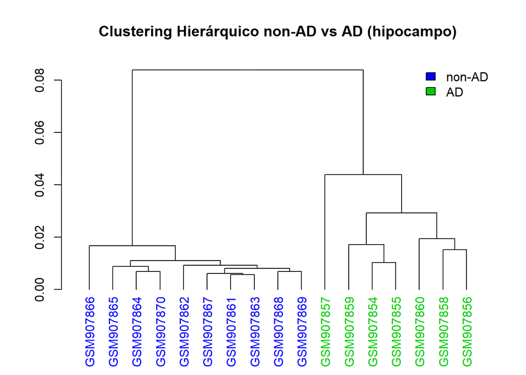

```r
cHipo=cor(dados.Hipo, method = "pearson")
dHipo = as.dist(1-cHipo)
hc.Hipo = hclust(dHipo)
dend.Hipo <- as.dendrogram(hc.Hipo)
colors_to_use <- (as.numeric(subsethipo$disease.state)+2)
colors_to_use <- colors_to_use[order.dendrogram(dend.Hipo)]
labels_colors(dend.Hipo) <- colors_to_use
plot(dend.Hipo, main = "Clustering Hierárquico non-AD vs AD (hipocampo)")
legend('topright', c("non-AD","AD"), bty = "n", fill = c(4, 3))
```

Pelo *clustering* verifica-se que é possível separar as amostras provenientes de indivíduos com AD das amostras de controlo no hipocampo em dois *clusters*. Desta forma, conclui-se que os genes correspondentes a amostras de indivíduos com AD apresentam um nível de expressão mais próximo entre si e mais afastado dos genes que provêm de amostras de controlo. Esta divisão era esperado, pois está concordante com os resultados da análise de expressão diferencial.

*Heatmap*:

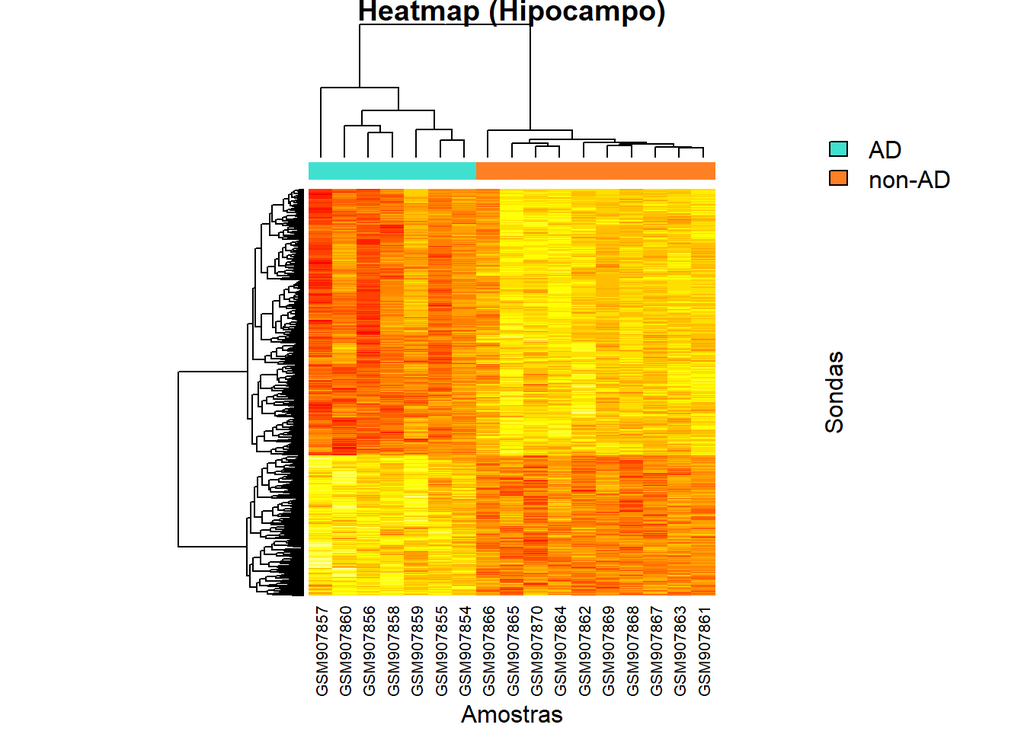

```r
tissuecolorsh <- unlist(lapply(Hipo.todos$disease.state, color.map.tissue))
heatmap(dados.Hipo,ColSideColors = tissuecolorsh, cexRow = 0.5, distfun = dist.fun, hclustfun = clust.fun, labRow = F, margins = c(7,7),
        ylab = "Sondas", xlab = "Amostras", main = "Heatmap (Hipocampo)")
legend("topright",legend=c("AD","non-AD"), bty="n",fill = c("turquoise","chocolate1"))
```

**Figura 6 -** *Heatmap* dos dados de expressão do hipocampo.

Analisando o *heatmap*, verifica-se uma evidente separação das amostras, tal como no *cluster* anterior. Para além disso, observa-se vários agrupamentos dos genes, que parecem estar agrupados consoante os seus níveis de expressão, já que se percebe uma grande porção com uma côr mais intensa (genes sobreexpressos) à esquerda do gráfico pertecente às amostras AD e uma porção com côr menos intensa (genes subexpressos) abaixo da anterior.

```r
genesT.todos = diffATemp[which(diffATemp$adj.P.Val < 0.05),]
Temp.todos = subsethipo[rownames(genesT.todos),]
dados.Temp = exprs(Temp.todos)
```

*Cluster*:

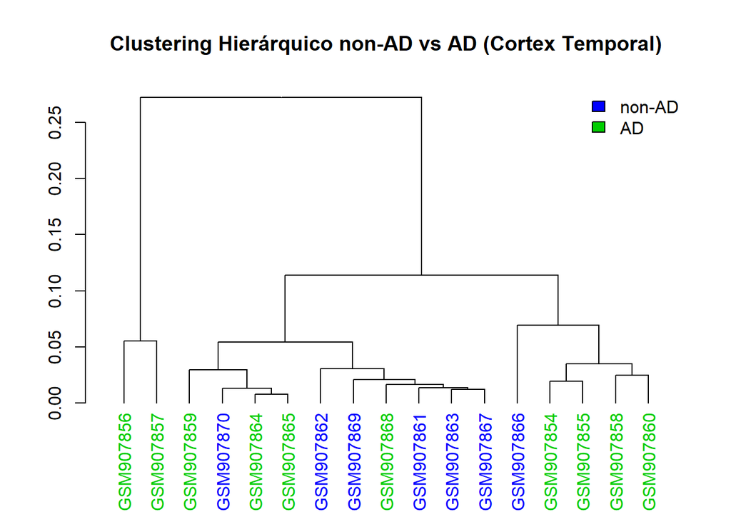

```r
cTemp=cor(dados.Temp, method = "pearson")
dTemp = as.dist(1-cTemp)
hc.Temp = hclust(dTemp)
dend.Temp <- as.dendrogram(hc.Temp)
colors_to_use <- (as.numeric(subsetTemp$disease.state)+2)
colors_to_use <- colors_to_use[order.dendrogram(dend.Temp)]
labels_colors(dend.Temp) <- colors_to_use
plot(dend.Temp, main = "Clustering Hierárquico non-AD vs AD (Cortex Temporal)")
legend('topright', c("non-AD","AD"), bty = "n", fill = c(4, 3))
```

*Heatmap*:

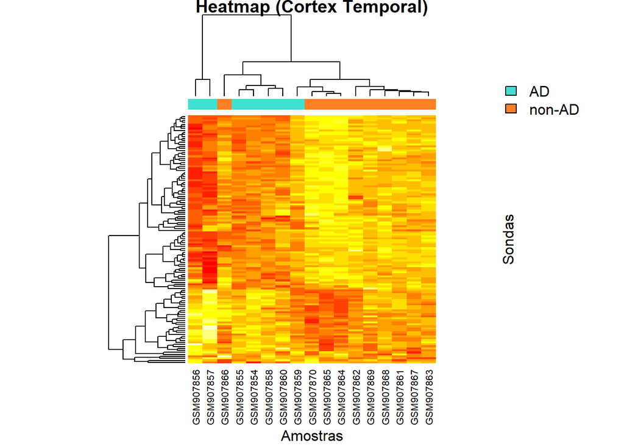

```r
tissuecolorst <- unlist(lapply(Temp.todos$disease.state, color.map.tissue))
heatmap(dados.Temp,ColSideColors = tissuecolorst, cexRow = 0.5, distfun = dist.fun, hclustfun = clust.fun, labRow = F, margins = c(7,7),
        ylab = "Sondas", xlab = "Amostras", main = "Heatmap (Cortex Temporal)")

legend("topright",legend=c("AD","non-AD"), bty="n",fill = c("turquoise","chocolate1"))
```

# 6 **Análise preditiva**

## 6.1 **Para o estado de doença**

### 6.1.1 **Análise dos K vizinhos mais próximos**

```r
model_knn = train(t(exprs(eset.f)), eset.f$disease.state, method = "knn", trControl=trainControl("cv", number = 5))
pred_knn = predict(model_knn, t(exprs(eset.f)))
mk1=confusionMatrix(pred_knn, eset.f$disease.state)
mk1$table; mk1$overal[1]
```

```
##                          Reference
## Prediction                Alzheimer's disease non-Alzheimer's disease
##   Alzheimer's disease                      21                       5
##   non-Alzheimer's disease                  11                      42
```

```
##  Accuracy
## 0.7974684
```

### 6.1.2 **Árvores de Decisão**

```r
model_tree = train(t(exprs(eset.f)), eset.f$disease.state, method = "rpart", trControl=trainControl("cv", number = 5))
pred_tree = predict(model_tree, t(exprs(eset.f)))
mt1 = confusionMatrix(pred_tree, eset.f$disease.state)
mt1$table; mt1$overal[1]
```

```
##                          Reference
## Prediction                Alzheimer's disease non-Alzheimer's disease
##   Alzheimer's disease                      23                       1
##   non-Alzheimer's disease                   9                      46
```

```
##  Accuracy
## 0.8734177
```

Este modelo previu o estado de doença com uma *Accuracy* de, aproximadamente, 87.3%.

### 6.1.3 **Máquinas de Vetores de Suportes (SVM’s)**

```r
model_svm = train(t(exprs(eset.f)), eset.f$disease.state, method = "svmLinear", trControl=trainControl("cv", number = 5))
pred_svm = predict(model_svm, t(exprs(eset.f)))
ms1=confusionMatrix(pred_svm, eset.f$disease.state)
ms1$table; ms1$overal[1]
```

```
##                          Reference
## Prediction                Alzheimer's disease non-Alzheimer's disease
##   Alzheimer's disease                      32                       0
##   non-Alzheimer's disease                   0                      47
```

```
## Accuracy
##        1
```

Este modelo previu o estado de doença com uma *Accuracy* de 100%, acertando na classificação de todos os exemplos.

## 6.2 **Para o tipo de tecido**

### 6.2.1 **Método dos K vizinhos mais próximos**

```r
model_knn2 = train(t(exprs(eset.f)), eset.f$tissue, method = "knn", trControl=trainControl("cv", number = 5))
pred_knn2 = predict(model_knn2, t(exprs(eset.f)))
mk2=confusionMatrix(pred_knn2, eset.f$tissue)
mk2$table; mk2$overal[1]
```

```
##                  Reference
## Prediction        frontal cortex hippocampus temporal cortex
##   frontal cortex              32           0               3
##   hippocampus                  1          13               0
##   temporal cortex              0           4              26
```

```
##  Accuracy
## 0.8987342
```

### 6.2.2 **Árvores de Decisão**

```r
model_tree2 = train(t(exprs(eset.f)), eset.f$tissue, method = "rpart", trControl=trainControl("cv", number = 5))
pred_tree2 = predict(model_tree2, t(exprs(eset.f)))
mt2=confusionMatrix(pred_tree2, eset.f$tissue)
mt2$table; mt2$overal[1]
```

```
##                  Reference
## Prediction        frontal cortex hippocampus temporal cortex
##   frontal cortex              33           0               0
##   hippocampus                  0          17               0
##   temporal cortex              0           0              29
```

```
## Accuracy
##        1
```

Este modelo previu o tipo de tecido com uma *Accuracy* de 100%.

### 6.2.3 **Máquinas de Vetores de Suportes (SVM’s)**

```r
model_svm2 = train(t(exprs(eset.f)), eset.f$tissue, method = "svmLinear", trControl=trainControl("cv", number = 5))
pred_svm2 = predict(model_svm2, t(exprs(eset.f)))
ms2=confusionMatrix(pred_svm2, eset.f$tissue)
ms2$table; ms2$overal[1]
```

```
##                  Reference
## Prediction        frontal cortex hippocampus temporal cortex
##   frontal cortex              33           0               0
##   hippocampus                  0          17               0
##   temporal cortex              0           0              29
```

```
## Accuracy
##        1
```

Este modelo também previu o tipo de tecido com uma *Accuracy* de 100%.

## 6.3 **Para o género**

### 6.3.1 **Método dos K vizinhos mais próximos**

```r
model_knn3 = train(t(exprs(eset.f)), eset.f$gender, method = "knn", trControl=trainControl("cv", number = 5))
pred_knn3 = predict(model_knn3, t(exprs(eset.f)))
mk3 = confusionMatrix(pred_knn3, eset.f$gender)
mk3$table; mk3$overal[1]
```

```
##           Reference
## Prediction female male
##     female     42    2
##     male        0   35
```

```
##  Accuracy
## 0.9746835
```

Na previsão do género, este modelo obteve uma *Accuracy* de 97.5%, aproximadamente.

### 6.3.2 **Árvores de Decisão**

```r
model_tree3 = train(t(exprs(eset.f)), eset.f$gender, method = "rpart", trControl=trainControl("cv", number = 5))
pred_tree3 = predict(model_tree3, t(exprs(eset.f)))
mt3=confusionMatrix(pred_tree3, eset.f$gender)
mt3$table; mt3$overal[1]
```

```
##           Reference
## Prediction female male
##     female     42    0
##     male        0   37
```

```
## Accuracy
##        1
```

Este modelo previu o género com uma *Accuracy* de 100%.

### 6.3.3 **Máquinas de Vetores de Suportes (SVM’s)**

```r
model_svm3 = train(t(exprs(eset.f)), eset.f$gender, method = "svmLinear", trControl=trainControl("cv", number = 5))
pred_svm3 = predict(model_svm3, t(exprs(eset.f)))
ms3 = confusionMatrix(pred_svm3, eset.f$gender)
ms3$table; ms3$overal[1]
```

```
##           Reference
## Prediction female male
##     female     42    0
##     male        0   37
```

```
## Accuracy
##        1
```

Por fim, este modelo também previu o género com uma *Accuracy* de 100%. Deste modo, é possível verificar que todos os métodos utilizados apresentam bons resultados, sendo que a melhor previsão foi do modelo de SVM’s, que obteve 100% de *Accuracy* nos três tipos de análise, ou seja, acertou na classificação de estado de doença, de tecido e de género de todas as amostras.

# 7 Conclusão

A doença de Alzheimer é considerada uma das doenças do mundo moderno, tendo a sua incidência e prevalência vindo a aumentar devido ao envelhecimento da população. Contudo, apesar dos vários estudos nesta área que tentam perceber a sua patofisiologia e numa última instância encontrar uma cura, a causa desta doença continua um mistério. Desta forma, a análise de expressão diferencial dos tecidos mais afetados por esta doença é fundamental. Pela análise feita, foi possível inferir algumas alterações relacionadas com a sintomatologia da doença e relacioná-las com aquilo que já se sabe sobre o processo de degeneração neuronal.

Consideramos que cumprimos os objetivos propostos e que este trabalho nos enriqueceu em termos de conhecimento sobre as ferramentas do Rstudio, rmarkdown e doença de Alzheimer.

Ainda, verificamos que o hipocampo é o tecido com maior expressão diferencial de genes entre AD e non-AD, corroborando a conclusão do artigo analisado, e que, como esperado, existe diferença na expressão entre sexo feminino e masculino, o que pode explicar a diferente incidência encontrada nos dois sexos.

# 8 Bibliografia

1 - M. Hokama, S. Oka, J. Leon, T. Ninomiya, H. Honda, K. Sasaki, T. Iwaki, T. Ohara, T. Sasaki, F. M. LaFerla, Y. Kiyohara, Y. Nakabeppu, Altered Expression of Diabetes-Related Genes in Alzheimer’s Disease Brains: The Hisayama Study, Cerebral Cortex September (2014); 24:2476-2488

2 - Matsuzaki T, Sasaki K, Tanizaki Y, Hata J, Fujimi K, Matsui Y, Sekita A, Suzuki S, Kanba S, Kiyohara Y et al. 2010. Insulin resistance is associated with the pathology of Alzheimer disease: the Hisayama study. Neurology. 75:764-770.

3 - S. E Lakhan, Jun 13, 2017, Medscape: Alzheimer disease. Acedido em 5/06/2017. http://emedicine.medscape.com/article/1134817-overview#a6

4 - S. E Lakhan, Jun 13, 2017, Medscape: Alzheimer disease. Acedido em 5/06/2017. http://emedicine.medscape.com/article/1134817-overview#a4